# UMAP on some simple datasets

This is part of the documentation for [UWOT](https://github.com/jlmelville/uwot).

The distill publication [How to Use t-SNE Effectively](https://distill.pub/2016/misread-tsne/) provides some interactive examples of t-SNE on a variety of simple datasets and demonstrates the effect of changing its hyperparameters, mainly the perplexity, which acts like a continuous version of the `n_neighbors` parameter in UMAP.

Below, I will repeat some results using UMAP instead of t-SNE, which might highlight some differences between the two methods. Sadly, there won’t be any fancy in-browser interactive demos.

The datasets used in the distill publication are available translated to R in the snedata package.

UMAP results are all run with the `n_neighbors` parameter set to match the `perplexity` used in t-SNE all other parameters left at their default values. There are two minor exceptions: in UMAP, a point is a neighbor of itself, which isn’t the case with perplexity. This doesn’t make much difference for large perplexities, but for the low perplexity values of 2 and 5, I use `n_neighbors = 3` and `n_neighbors = 6`, respectively.

I won’t repeat the t-SNE results here. You should refer back to the distill page to compare. I have kept the same order of datasets and used the same colors so it should be straightforward to keep things tracked.

## Grid

A 2D grid with regularly spaced points.

```r
grid2d <- snedata::grid_data(n = 20)
```

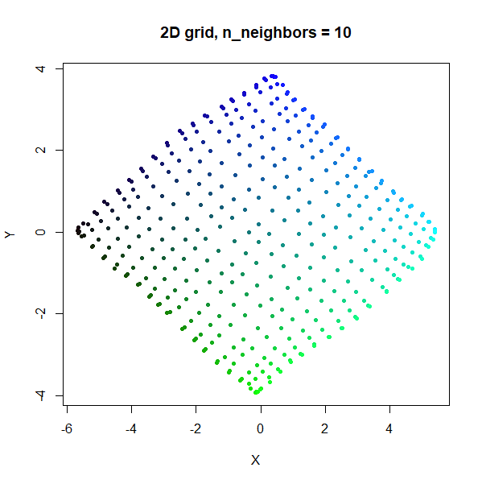

Like t-SNE, UMAP tends to expand denser regions of data, so there is a bigger gap between points in the middle of the grid.

## 2 Clusters

Two 2D Gaussian clusters of equal variance, and 50 points each.

```r
gauss2d <- snedata::two_clusters_data(n = 50, dim = 2)
```

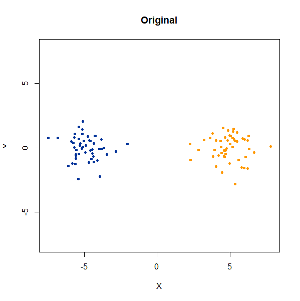

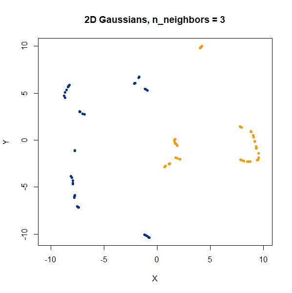

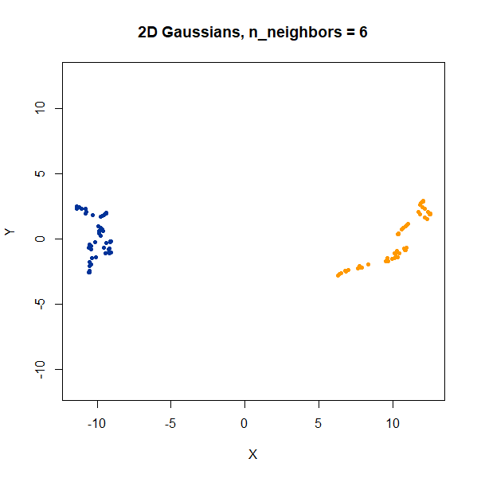

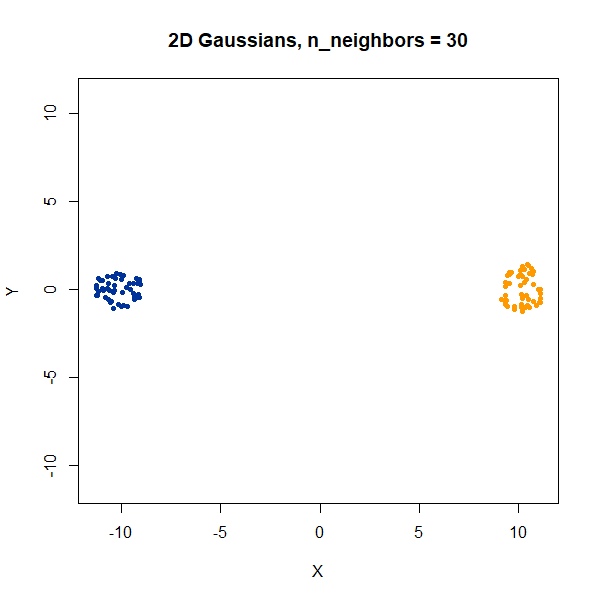

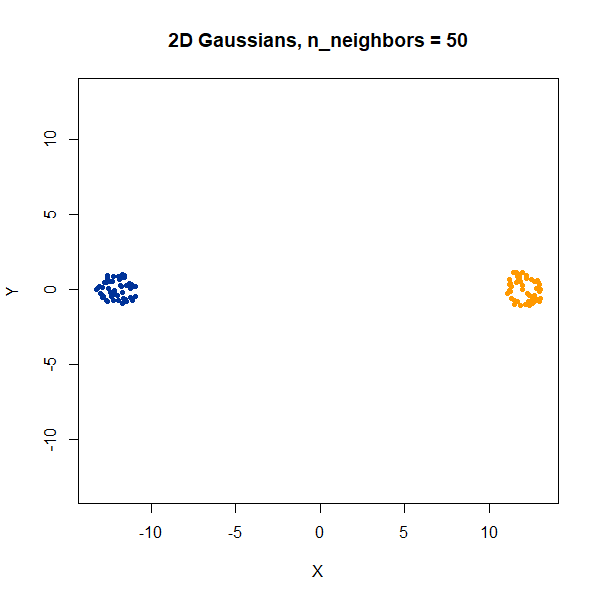

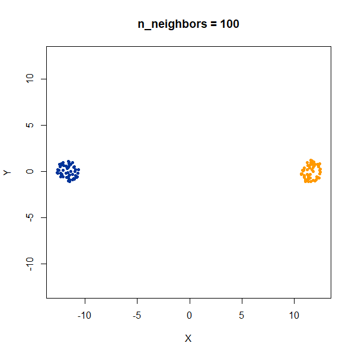

Setting `n_neighbors` too low clearly gives results which are too local.

## Cluster Densities

In this example, one of the clusters (the yellow one) is much denser (and hence smaller) than the other.

```r
gauss2d_scale <- snedata::two_different_clusters_data(n = 75, scale = 10, dim = 2)
```

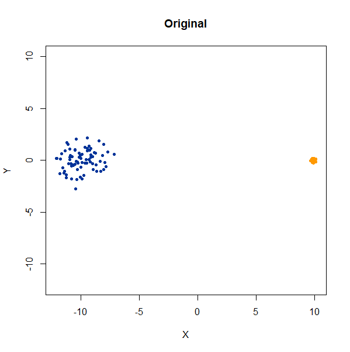

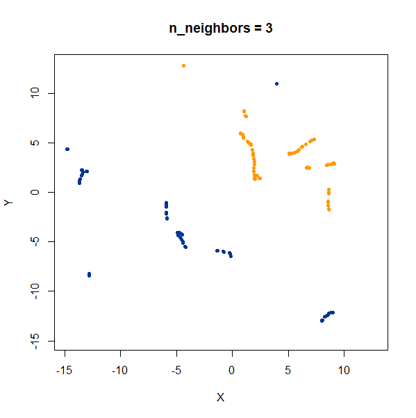

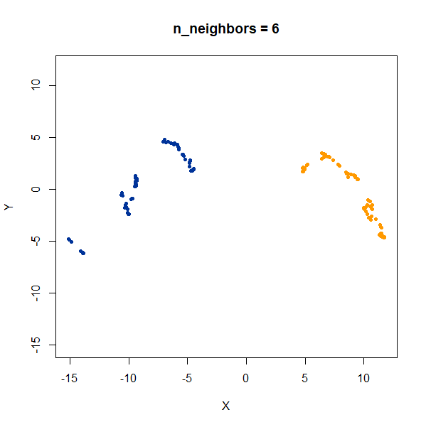

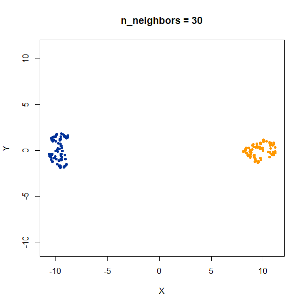

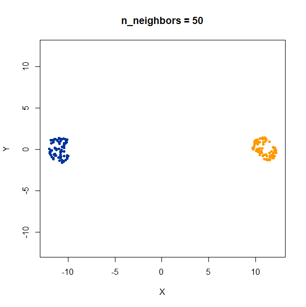

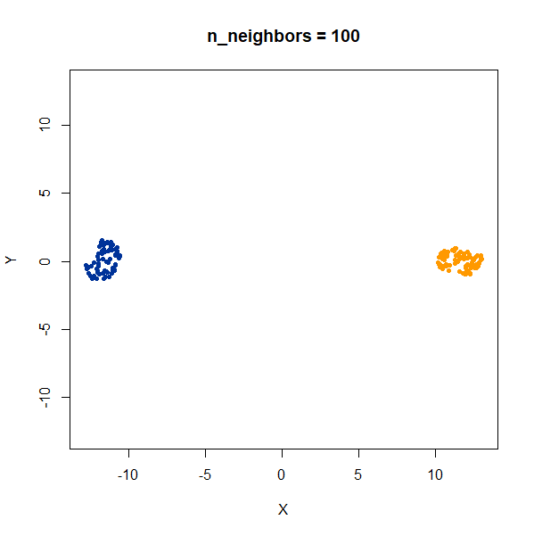

Again like t-SNE, UMAP does not reproduce the relative cluster densities.

## Cluster Size

```r
x100a <- snedata::gaussian_data(n = 100, dim = 50, color = "blue")
x1000b <- snedata::gaussian_data(n = 1000, dim = 50, color = "orange")
x1000b[, 1:50] <- x1000b[, 1:50] <- x1000b[, 1:50] + 10
x200 <- rbind(x100a, x100b)
x1100 <- rbind(x100a, x1000b)
```

As an aside, what about two clusters with the same density but different numbers of points? Below is an example with two clusters with equal sizes (100 points each), and then where the orange cluster contains 1000 points:

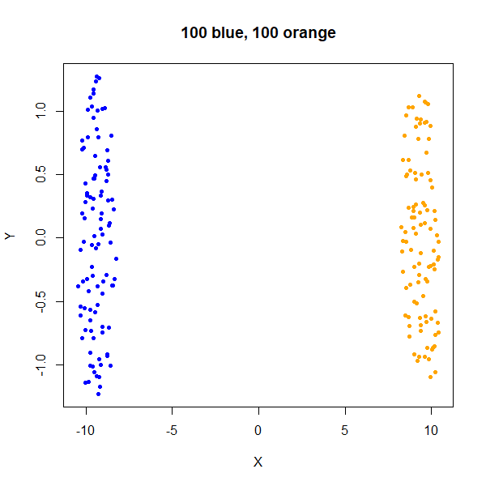

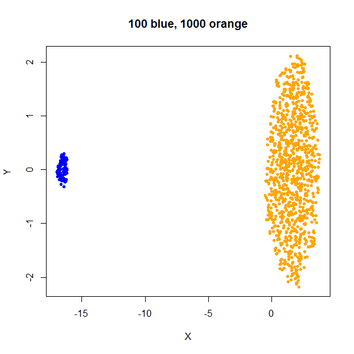

From this example you can see that UMAP will display clusters with more members as being larger. This can have implications for the visualization if you have a minority class that you are most interested in.

## Distances Between Clusters

In this example, we are back to gaussians with the same variances, but now one of them (the green one) is much further away than the other two.

```r
gauss_3clusters <- snedata::three_clusters_data(n = 50, dim = 2)
```

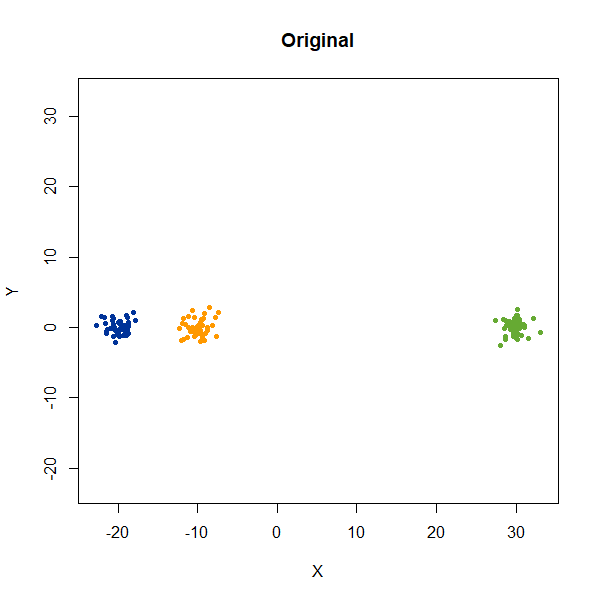

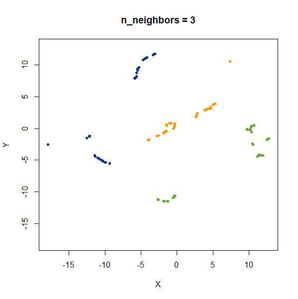

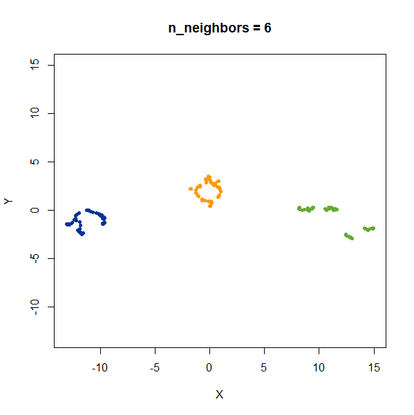

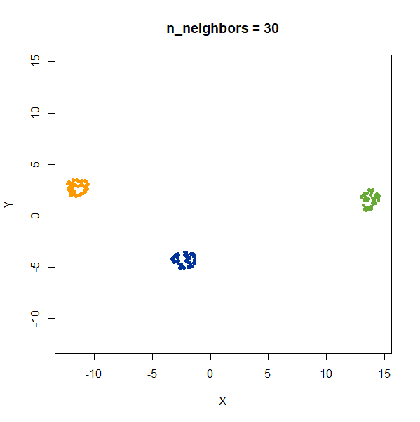

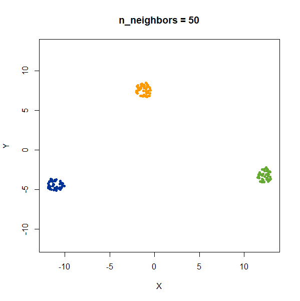

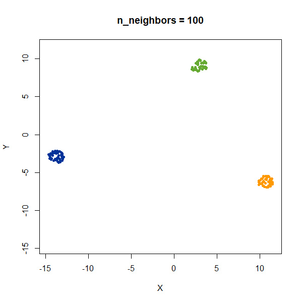

There’s not really any value of `n_neighbors` where the correct relative distances are reproduced. On the other hand, at least we don’t see any strange distortion of the size of the green cluster at high values for `n_neighbors`, where as the t-SNE results start showing distortions at high perplexity.

We then repeat with a larger number of points in each cluster:

```r
gauss_3clusters200 <- snedata::three_clusters_data(n = 200, dim = 2)
```

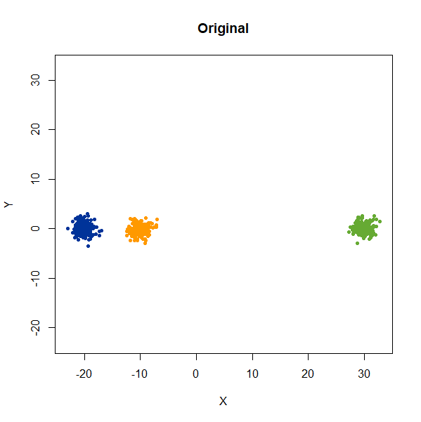

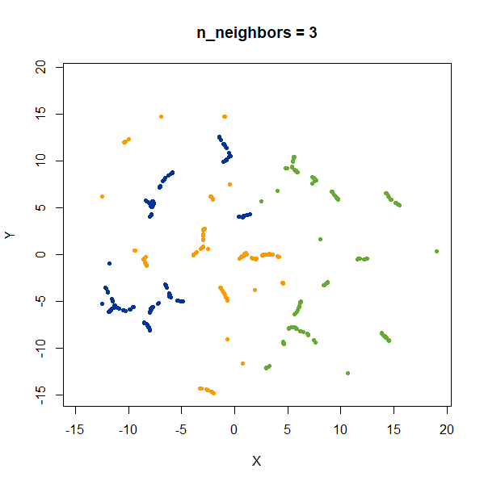

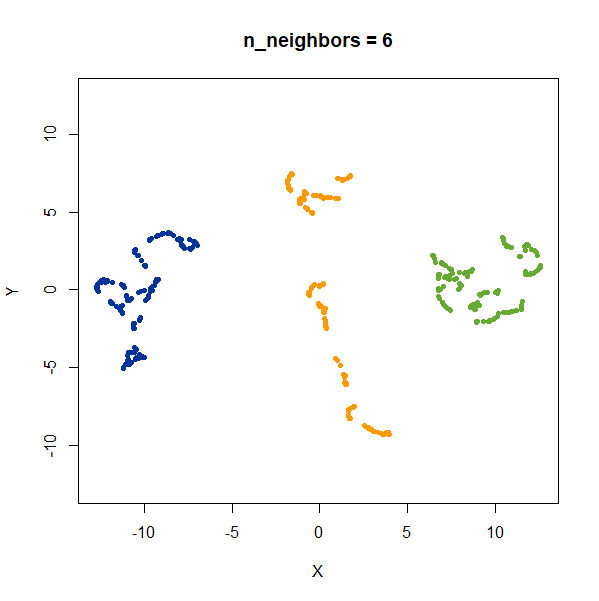

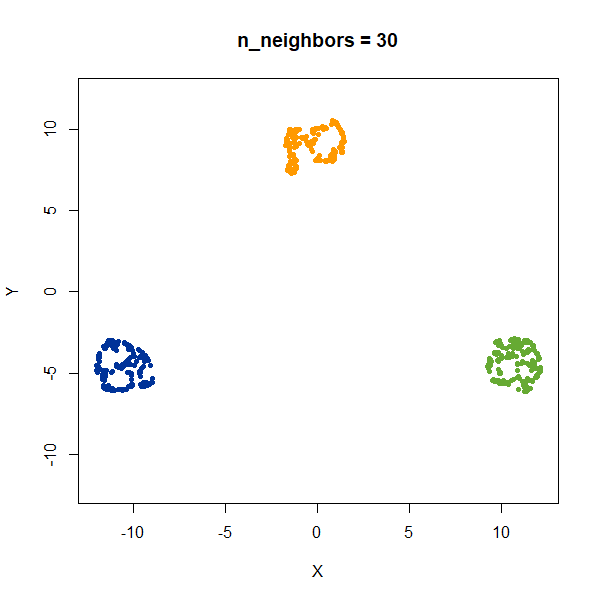

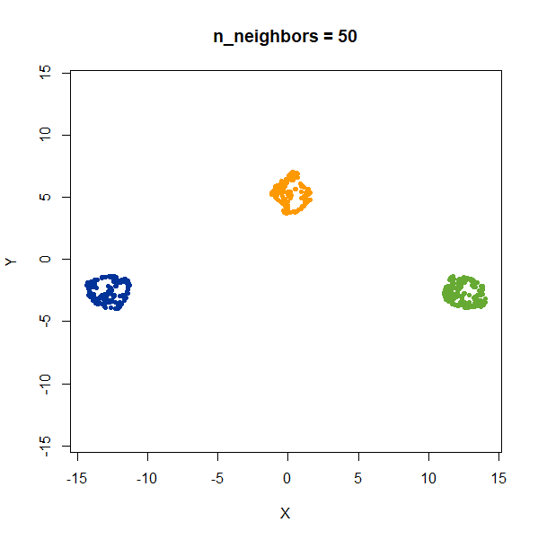

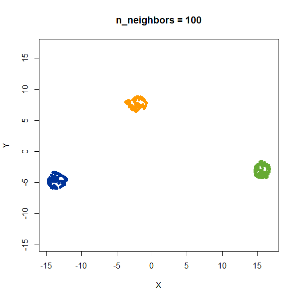

Results are very consistent with a sensible value of `n_neighbors`, but it’s clear that UMAP does not reproduce relative distances in this case.